# Assignment 3

Jatin Jain

**Data 624 - Predictive Analytics**

**Chapter 6**

```r
library(fpp2)
library(seasonal)
library(seasonalview)
```

## 6.2 The plastics data set consists of the monthly sales (in thousands) of product A for a plastics manufacturer for five years.

### a. Plot the time series of sales of product A. Can you identify seasonal fluctuations and/or a trend-cycle?

```r
help(plastics)
```

```r
plastics
```

```
##    Jan  Feb  Mar  Apr  May  Jun  Jul  Aug  Sep  Oct  Nov  Dec
## 1  742  697  776  898 1030 1107 1165 1216 1208 1131  971  783
## 2  741  700  774  932 1099 1223 1290 1349 1341 1296 1066  901
## 3  896  793  885 1055 1204 1326 1303 1436 1473 1453 1170 1023
## 4  951  861  938 1109 1274 1422 1486 1555 1604 1600 1403 1209
## 5 1030 1032 1126 1285 1468 1637 1611 1608 1528 1420 1119 1013
```

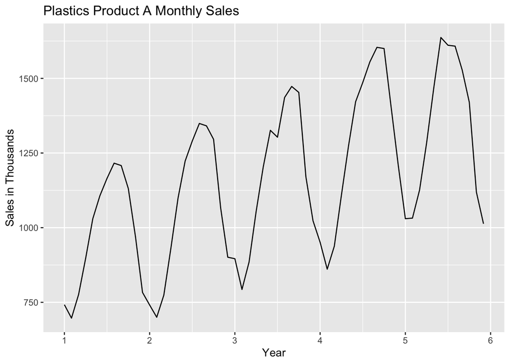

```r
autoplot(plastics) + ggtitle('Plastics Product A Monthly Sales') + ylab('Sales in Thousands') + xlab('Year')
```

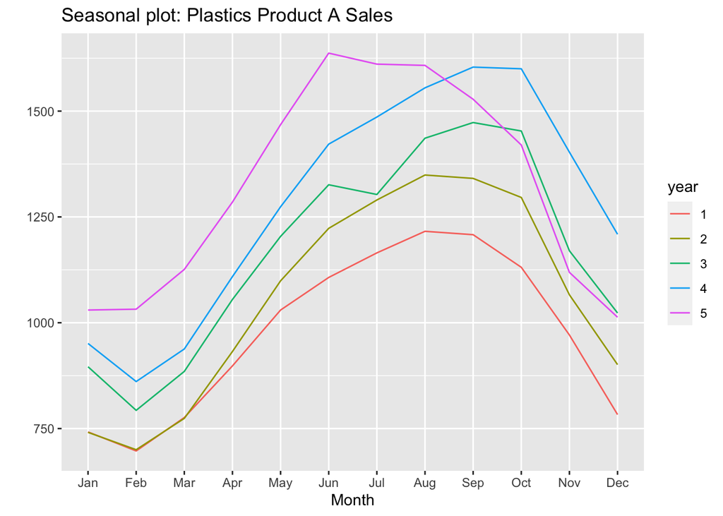

```r
ggseasonplot(plastics) + ggtitle('Seasonal plot: Plastics Product A Sales')
```

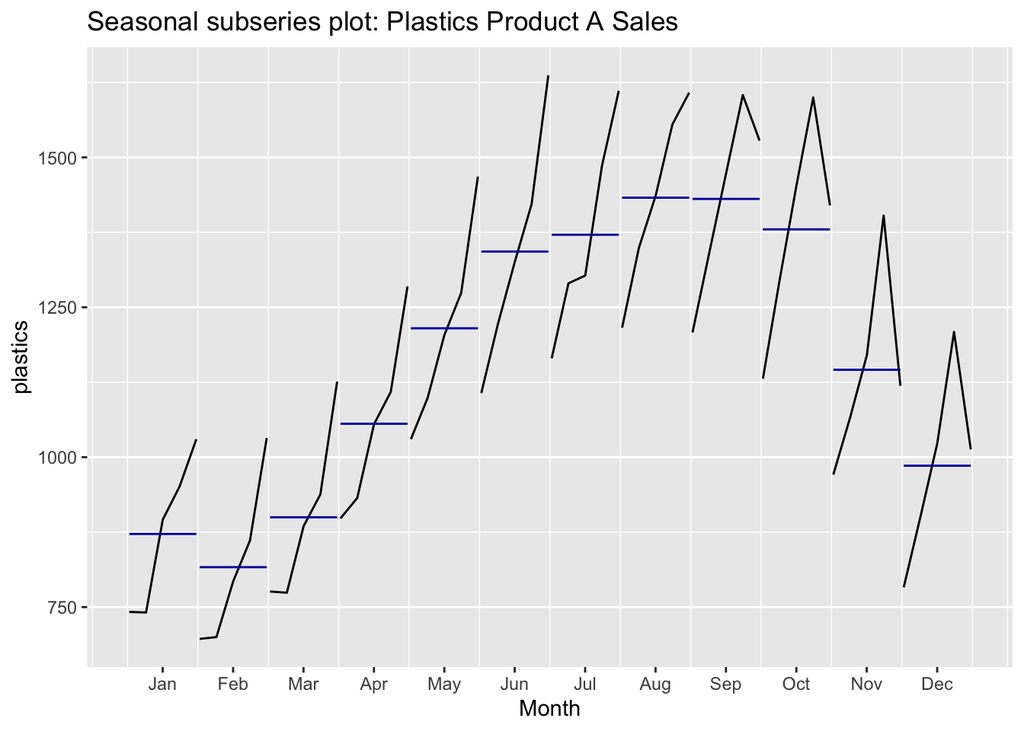

```r
ggsubseriesplot(plastics) + ggtitle('Seasonal subseries plot: Plastics Product A Sales')
```

#### * There is definitely a seasonal pattern here. The sales typically are the lowest in February, and then the sales start to increase until it reach a maximum around the months of June through October. And the sales then decline after that. There is also a noticeable increasing trend through the years.

### b. Use a classical multiplicative decomposition to calculate the trend-cycle and seasonal indices.

```r
plastics.decomp <- decompose(plastics, type='multiplicative')
plastics.decomp$trend
```

```
##         Jan       Feb       Mar       Apr       May       Jun       Jul
## 1        NA        NA        NA        NA        NA        NA  976.9583
## 2 1000.4583 1011.2083 1022.2917 1034.7083 1045.5417 1054.4167 1065.7917
## 3 1117.3750 1121.5417 1130.6667 1142.7083 1153.5833 1163.0000 1170.3750
## 4 1208.7083 1221.2917 1231.7083 1243.2917 1259.1250 1276.5833 1287.6250
## 5 1374.7917 1382.2083 1381.2500 1370.5833 1351.2500 1331.2500        NA
##         Aug       Sep       Oct       Nov       Dec
## 1  977.0417  977.0833  978.4167  982.7083  990.4167
## 2 1076.1250 1084.6250 1094.3750 1103.8750 1112.5417
## 3 1175.5000 1180.5417 1185.0000 1190.1667 1197.0833
## 4 1298.0417 1313.0000 1328.1667 1343.5833 1360.6250
## 5        NA        NA        NA        NA        NA
```

```r
plastics.decomp$seasonal
```

```
##         Jan       Feb       Mar       Apr       May       Jun       Jul
## 1 0.7670466 0.7103357 0.7765294 0.9103112 1.0447386 1.1570026 1.1636317
## 2 0.7670466 0.7103357 0.7765294 0.9103112 1.0447386 1.1570026 1.1636317
## 3 0.7670466 0.7103357 0.7765294 0.9103112 1.0447386 1.1570026 1.1636317
## 4 0.7670466 0.7103357 0.7765294 0.9103112 1.0447386 1.1570026 1.1636317
## 5 0.7670466 0.7103357 0.7765294 0.9103112 1.0447386 1.1570026 1.1636317
##         Aug       Sep       Oct       Nov       Dec
## 1 1.2252952 1.2313635 1.1887444 0.9919176 0.8330834
## 2 1.2252952 1.2313635 1.1887444 0.9919176 0.8330834
## 3 1.2252952 1.2313635 1.1887444 0.9919176 0.8330834
## 4 1.2252952 1.2313635 1.1887444 0.9919176 0.8330834
## 5 1.2252952 1.2313635 1.1887444 0.9919176 0.8330834
```

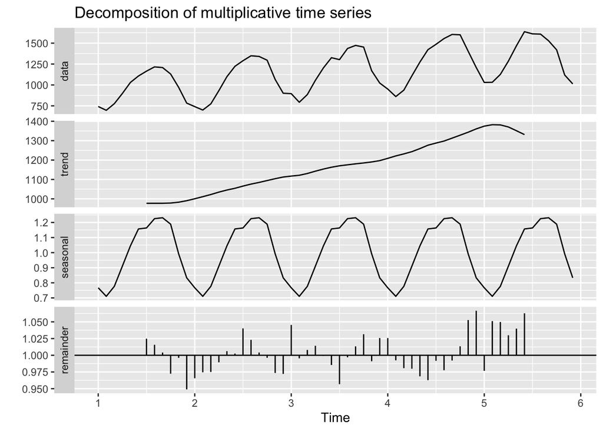

```r
autoplot(plastics.decomp)
```

### c. Do the results support the graphical interpretation from part a?

#### * Yes. There is an apparent seasonal pattern and a increasing trend. There is a slight trend drop off in the 1st half of year 5, and the remainder plot suggests that the trend-cycle estimate underestimated after year 5.

### d. Compute and plot the seasonally adjusted data.

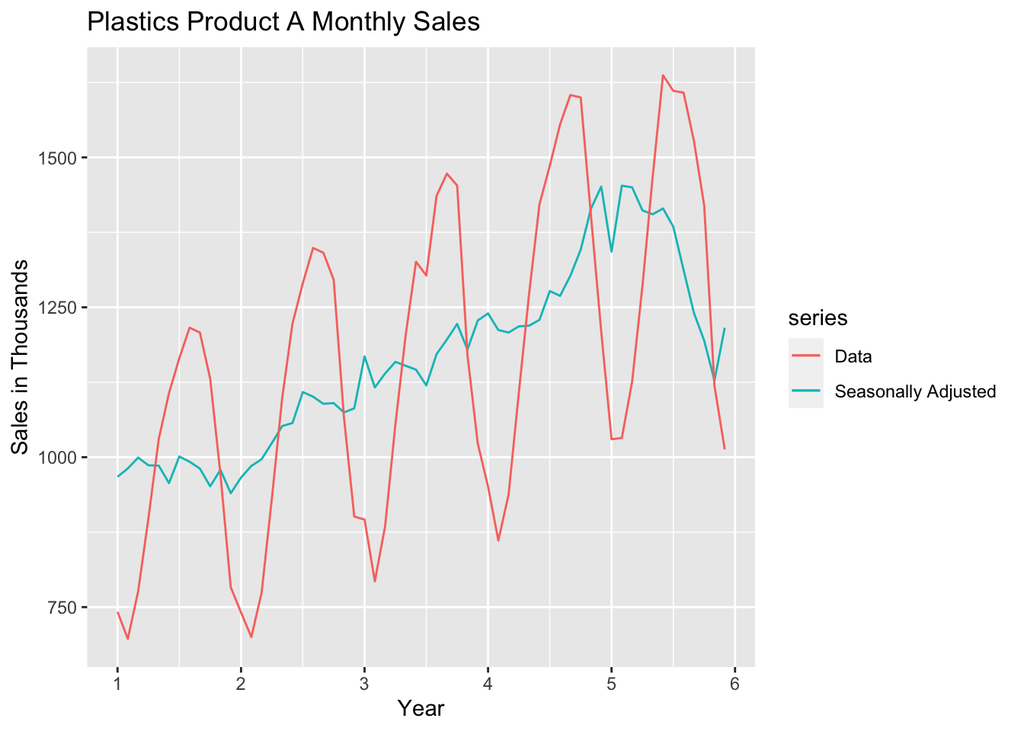

```r
plastics.sadj <- plastics / plastics.decomp$seasonal
autoplot(plastics.sadj, series='Seasonally Adjusted ') +
  autolayer(plastics, series='Data') + ggtitle('Plastics Product A Monthly Sales') +
  ylab('Sales in Thousands') + xlab('Year')
```

### f. Change one observation to be an outlier (e.g., add 500 to one observation), and recompute the seasonally adjusted data. What is the effect of the outlier?

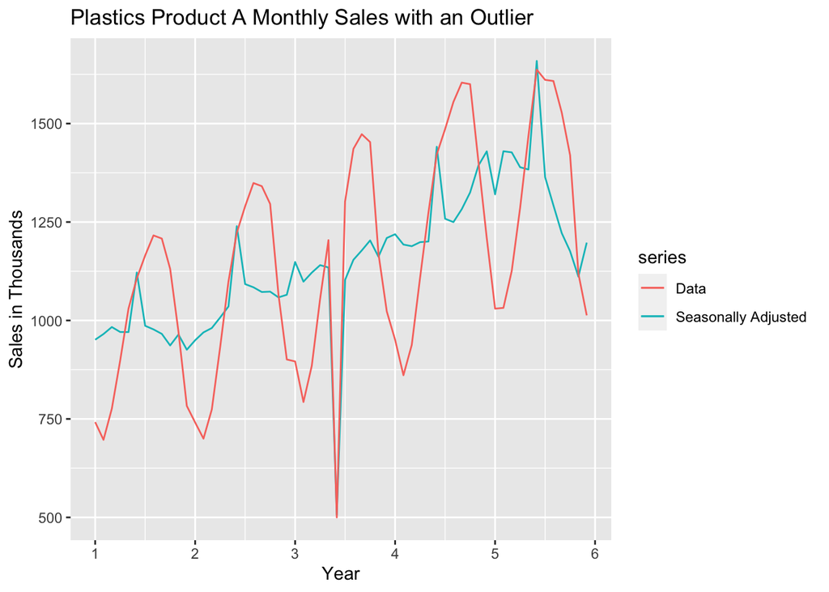

```r
plastics.out <- plastics
plastics.out[30] <- 500
plastics.out.decomp <- decompose(plastics.out, type='multiplicative')
plastics.out.sadj <- plastics.out / plastics.out.decomp$seasonal

autoplot(plastics.out.sadj, series='Seasonally Adjusted ') +
  autolayer(plastics.out, series='Data') +
  ggtitle('Plastics Product A Monthly Sales with an Outlier') +
  ylab('Sales in Thousands') +
  xlab('Year')
```

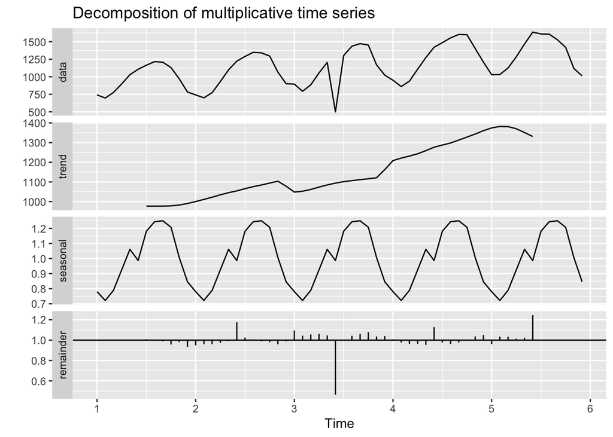

```r
autoplot(plastics.out.decomp)
```

#### * Changed the sales data in the 3rd year in the month of June from 1326 to 500.

#### * The outlier introduces a dip in the seasonal pattern in the month of June and a region of depression in the trend pattern 6 months before and after the month of June in year 3. The remainder plot also registers this large outlier.

### f. Does it make any difference if the outlier is near the end rather than in the middle of the time series?

#### * Introduced the outlier at the end of the 3rd year, instead of the middle.

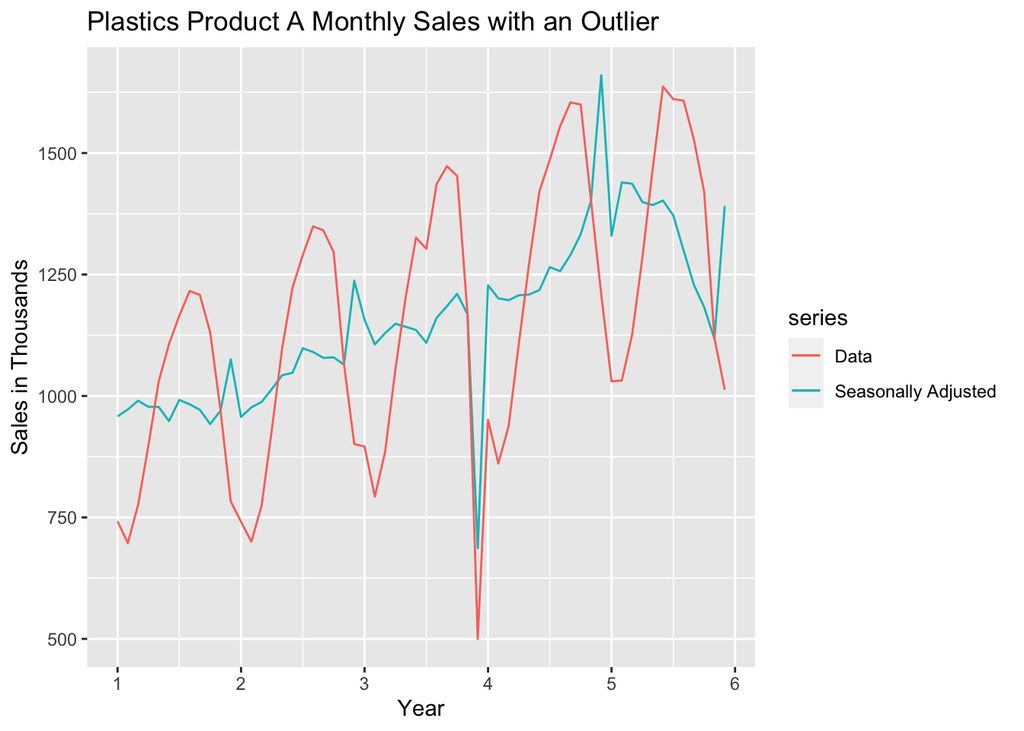

```r
plastics.out <- plastics
plastics.out[36] <- 500
plastics.out.decomp <- decompose(plastics.out, type='multiplicative')
plastics.out.sadj <- plastics.out / plastics.out.decomp$seasonal

autoplot(plastics.out.sadj, series='Seasonally Adjusted ') +
  autolayer(plastics.out, series='Data') +
  ggtitle('Plastics Product A Monthly Sales with an Outlier') +
  ylab('Sales in Thousands') +
  xlab('Year')
```

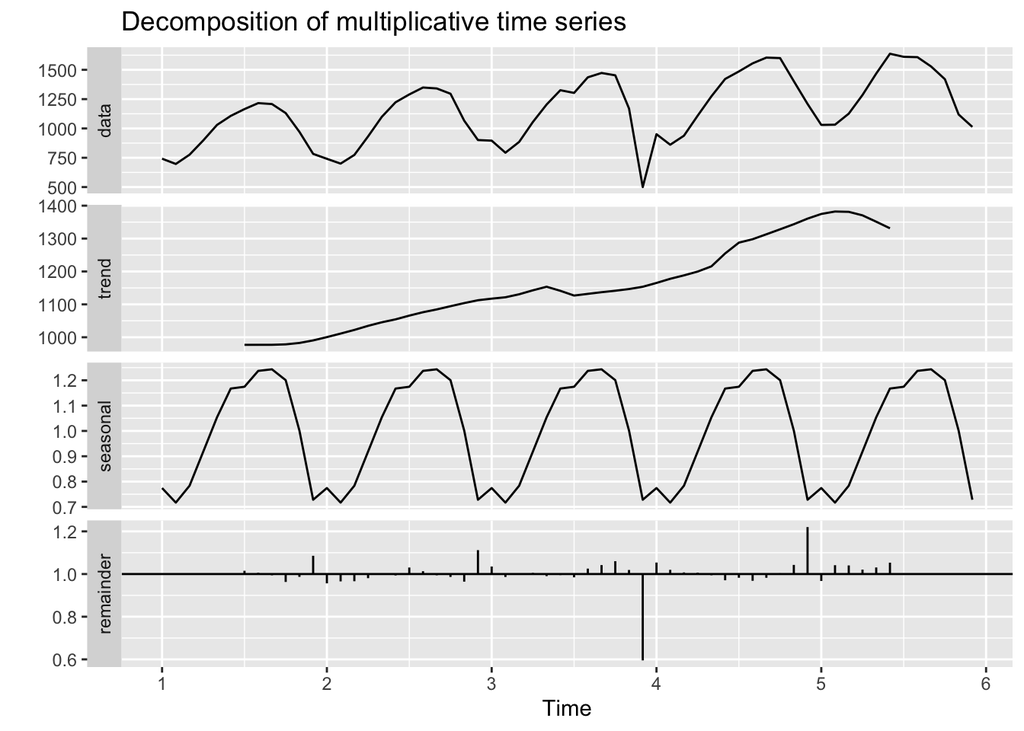

```r
autoplot(plastics.out.decomp)
```

#### * It changes the location of the dip in the seaonal pattern and the depression region in the trend. Overall, the effects still exist and just changes in magnitude.

## 6.3 Recall your retail time series data (from Exercise 3 in Section 2.10). Decompose the series using X11. Does it reveal any outliers, or unusual features that you had not noticed previously?

```r
retaildata <- readxl::read_excel("retail.xlsx", skip=1)
myts <- ts(retaildata[,"A3349873A"],
  frequency=12, start=c(1982,4))
myts.decomp <- seas(myts, x11='')
```

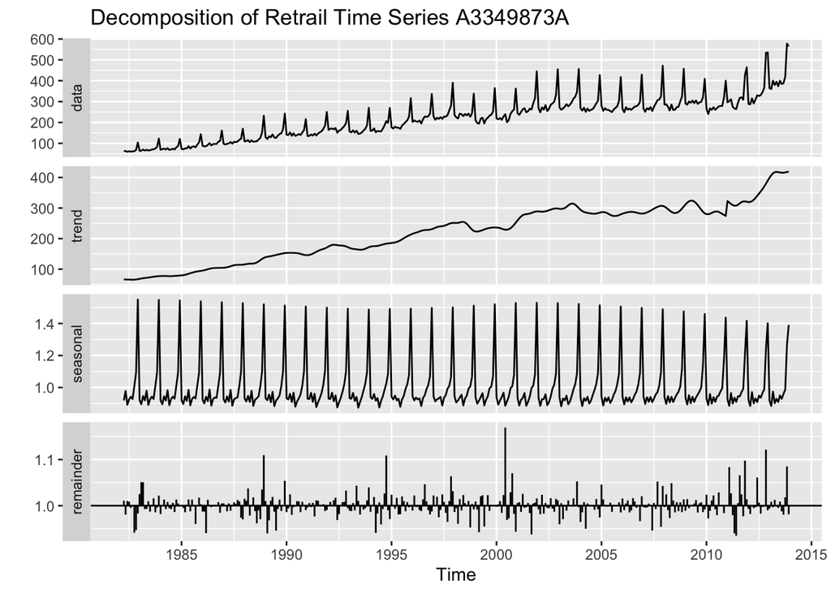

```r
autoplot(myts.decomp) +
  ggtitle('Decomposition of Retrail Time Series A3349873A')
```

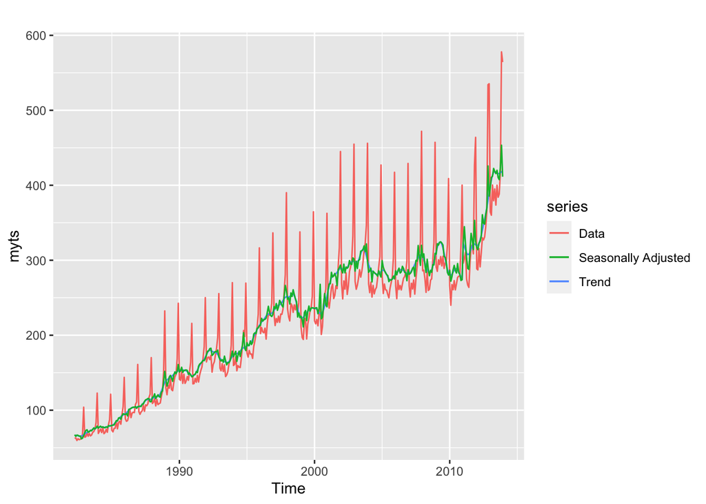

```r
autoplot(myts, series='Data') +
  autolayer(trendcycle(myts.decomp), series='Trend') +
  autolayer(seasadj(myts.decomp), series='Seasonally Adjusted')
```